# Using Test Statistics

### 1. T-Tests

T-tests are among the most frequently used tests in data analysis. They’re delightfully simple, and provide a robust example of how to examine the entire workflow of a data analysis. These are steps you’ll take with any analysis you do in the future, no matter how complex the model!

#### 1.1 One Sample T-Test

For a one sample t-test, we’re merely testing whether or not a vector of observations are different from zero, our null hypothesis. This can be a sample of observed values, it can be a sample of differences between paired treatments, anything!

Let’s look at the W&S data on blackbird immunoresponse before and after testosterone implants. So, first, load the data and visualize the change in immunoresponse.

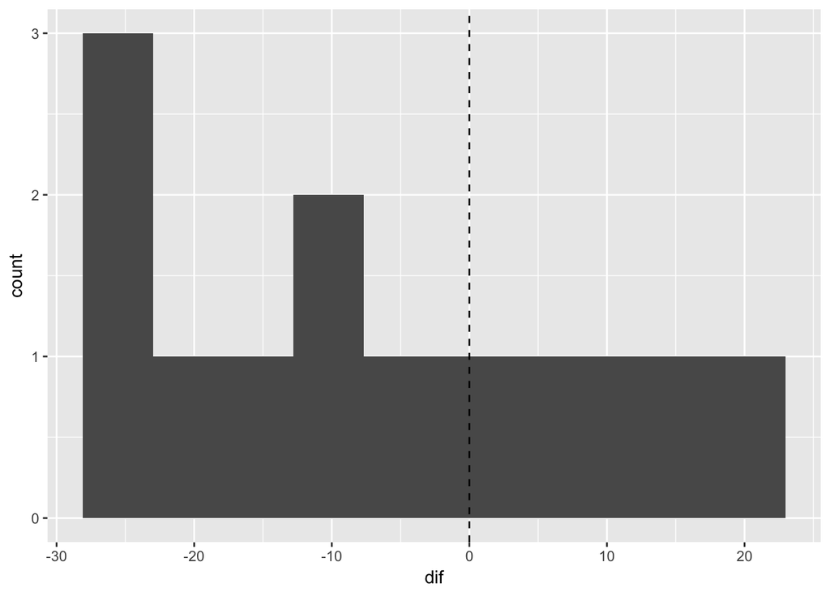

```r
library(dplyr)
library(readr)
library(ggplot2)

#We will need to add an individual bird identifier
blackbird <- read_csv("./data/12e2BlackbirdTestosterone.csv") %>%
  mutate(Bird = 1:n())

ggplot(data = blackbird, mapping=aes(x=dif)) +
  geom_histogram(bins=10) +
  geom_vline(xintercept=0, lty=2)
```

So, right away we can see the problem with the distribution of the data.

Let’s proceed and ignore it for the moment.

The `t.test()` function gives us a lot of options.

```r
t.test(x, y = NULL,
       alternative = c("two.sided", "less", "greater"),
       mu = 0, paired = FALSE, var.equal = FALSE,
       conf.level = 0.95, ...)
```

We can feed it different alternatives (it defaults to two=tails), specify a hypothesis we’re testing against (it defaults to a null hypothesis with mu=0), and we can give it either just a sample of observations, or also a vector with groups. We can also tell it whether we’re worried about equal variances, if we’re giving it paired data, and more.

In this case, for a one-sample t-test, we just want to feed it our differences.

```r
t.test(blackbird$dif)
```

```
##
##  One Sample t-test
##
## data:  blackbird$dif
## t = -1.5079, df = 12, p-value = 0.1575
## alternative hypothesis: true mean is not equal to 0
## 95 percent confidence interval:
##  -15.98626   2.90934
## sample estimates:
## mean of x
## -6.538462
```

That’s a fairly wonky output table, but we see all of the critical information - the value of t, our DF, our p-value, and both a mean estimate and confidence interval. Here we see a p-value of 0.157455 that suggests we fail to reject the null.

If you find this output ugly, there’s a wonderful package called `broom` that produces a standardized set of model output tidiers in a data frame format.

```r
library(broom)
tidy(t.test(blackbird$dif))
```

```
##    estimate statistic  p.value parameter  conf.low conf.high
## 1 -6.538462 -1.507873 0.157455        12 -15.98626   2.90934
##              method alternative
## 1 One Sample t-test   two.sided
```

More on `broom` next week.

#### 1.2 Two Sample T-Test

For a two sample t-test, we can feed in a vector of groups, or, `t.test()` is the first function that will take a *formula* for statistical tests. Let’s look at a data set examining the survival of juvenile chinook salmon (yum) in rivers with versus without brook trout.

First, we’ll load and plot the data.

```r
chinook <- read_csv("./data/12e4BrookTrout.csv")
```

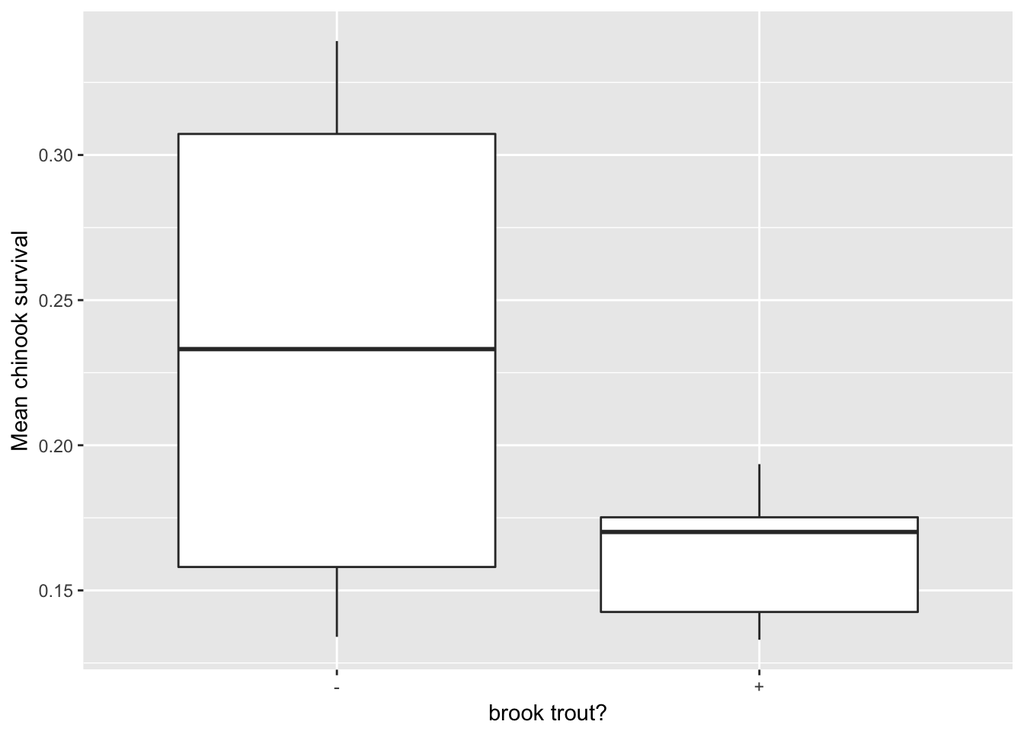

```r
ggplot(data=chinook, mapping=aes(x=`brook trout?`, y=`Mean chinook survival`)) +
  geom_boxplot()
```

We have some unequal variances in the data here, which is of note. We also have two groups.

As with base plot, R has a formula syntax that we can use to specify a relationship where we have a predictor and response. Broadly, it looks like:

$$response \sim predictor$$

We can use this syntax with our t.test function, as it also accepts formulae. So, here’s our two-sample unpaired t-test with unequal variances:

```r
chin_test <- t.test(`Mean chinook survival` ~ `brook trout?`, data = chinook,
       unequal.var = TRUE)

chin_test
```

```
##
##  Welch Two Sample t-test
##
## data:  Mean chinook survival by brook trout?
## t = 1.8718, df = 5.7256, p-value = 0.1127
## alternative hypothesis: true difference in means is not equal to 0
## 95 percent confidence interval:
##  -0.02298513  0.16548513
## sample estimates:
## mean in group - mean in group +
##       0.2340833       0.1628333
```

Great, we have our means per group, the difference between them, and we see we’re using a Welch’s t-test for unequal variance. Here we’d again fail to reject the null hypothesis.

If you want prettier output:

```r
tidy(chin_test)
```

```
##   estimate estimate1 estimate2 statistic   p.value parameter    conf.low
## 1  0.07125 0.2340833 0.1628333  1.871788 0.1127448  5.725576 -0.02298513
##   conf.high                  method alternative
## 1 0.1654851 Welch Two Sample t-test   two.sided
```

OK, not that much prettier, but you can put it in a table.

#### 1.3 Evaluating Residuals

So, we’ve ignored the assumption of normality up until now. Broadly, in any statistical model, error comes in as a residual value. So, often our data may not be normally distribted, but after accounting for predictors, we find that the *residuals* are. To test whether residuals are normal, we need to, well, create residuals!

For a t-test this is easy, as residuals are just means - either of a single column, or from groups. We can thus use `dplyr` here. So for our one-sample t-test of blackbirds

```r
library(dplyr)

blackbird <- blackbird %>%
  mutate(resid = dif - mean(dif))
```

For our two-sample t-test, we use `group_by` for group means.

```r
chinook <- chinook %>%
  group_by( `brook trout?`) %>%
  mutate(mean_survival_resid =
           `Mean chinook survival` - mean(`Mean chinook survival`)) %>%
  ungroup()
```

We can then evaluate for normality. Let’s use the blackbird example. First, we’d look at the distribution of residuals.

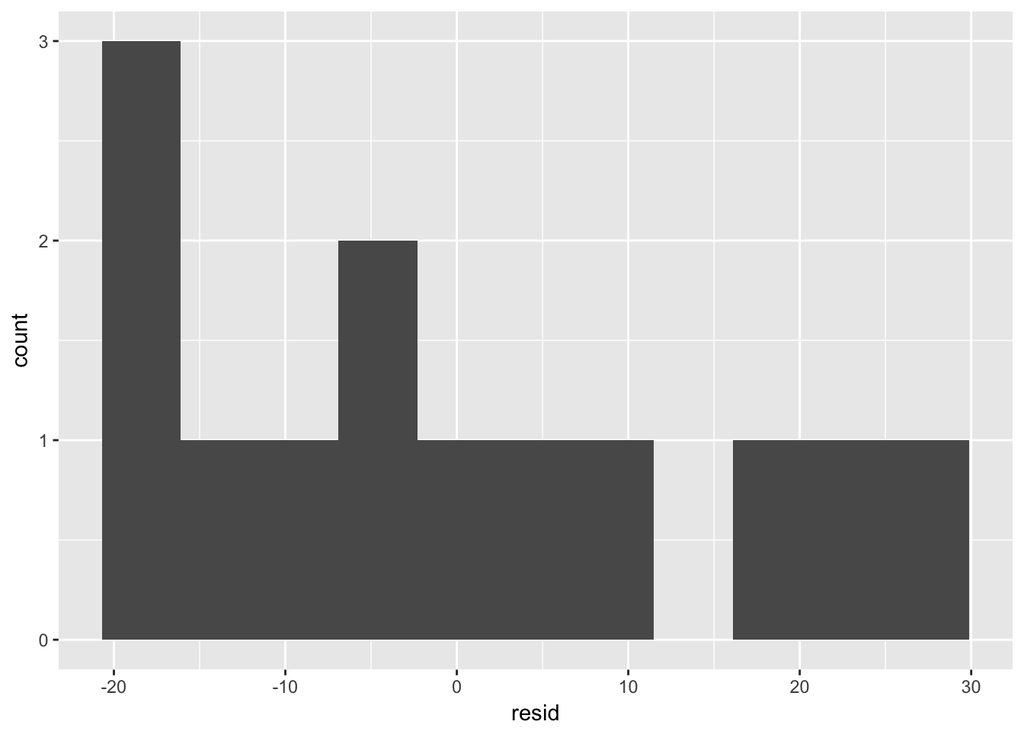

```r
ggplot(data = blackbird, mapping=aes(x=resid)) +
  geom_histogram(bins=11)
```

OK - still not looking good. But, who knows, this is a binned histogram. Maybe we need something more accurate - like a qqplot. For a qqplot, we invoke two functions in base plot (if we want the fit line - `ggplot2` still doesn’t do this, but give it time).

The functions are `qqnorm` and `qqline`. We use them sequentially.

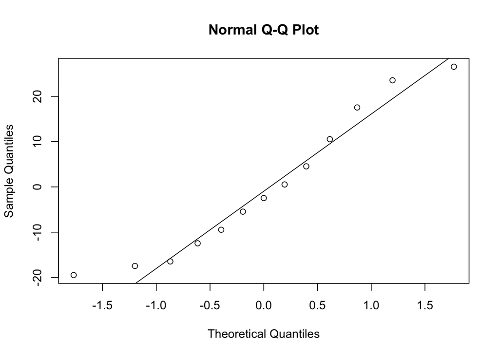

```r
qqnorm(blackbird$resid)
qqline(blackbird$resid)
```

Now we can see that systematic behavior in the lower tail.

We may still want to *put it to the test* as it were, with a Shapiro Wilk’s test. R provides a `shapiro.test()` functio for this.

```r
shapiro.test(blackbird$resid)
```

```
##
##  Shapiro-Wilk normality test
##
## data:  blackbird$resid
## W = 0.93148, p-value = 0.3563
```

OK, so, what does that p-value mean? In this case, it means we would fail to reject the null hypothesis that this data comes from a normal distribution. So, we should actually be OK going forward! This is one case where we don’t want to have a p value smaller than our alpha.

**Exercise** - repeat this normality analysis for the chinook salmon!

#### 1.3 Plotting results

For a one-sample t-test, plotting a result - a mean and SE - might not be necessary. But for a two-sample test, it’s highly informative! It should be the final step in any analysis in order to aid interpretation. Here, `ggplot2`’s stat_summary function is invaluable, as it defaults to plotting mean and standard errors.

```
## No summary function supplied, defaulting to `mean_se()
```

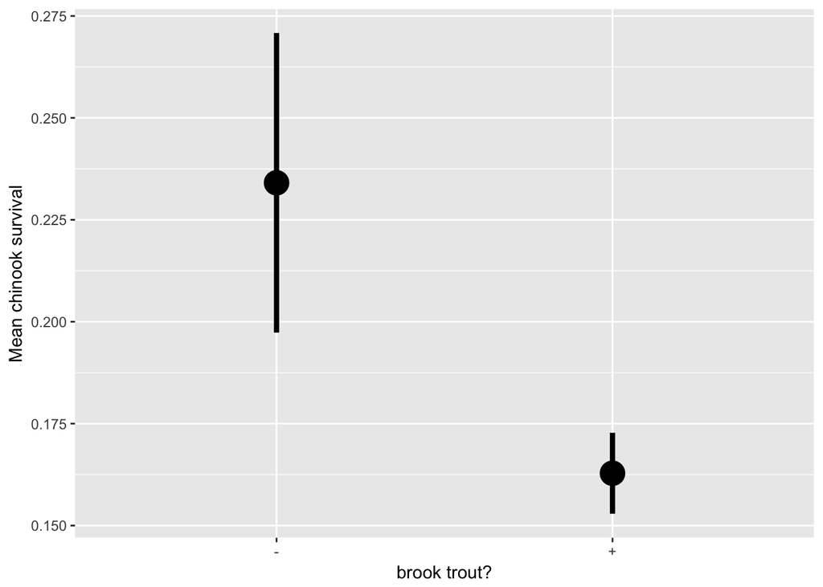

```r
salmon_means <- ggplot(data=chinook,
                       mapping=aes(x=`brook trout?`,
                                   y=`Mean chinook survival`)) +
  stat_summary(size=1.5)

salmon_means
```

Nice. If you want to see this relative to the data, you can still include it.

```
## No summary function supplied, defaulting to `mean_se()
```

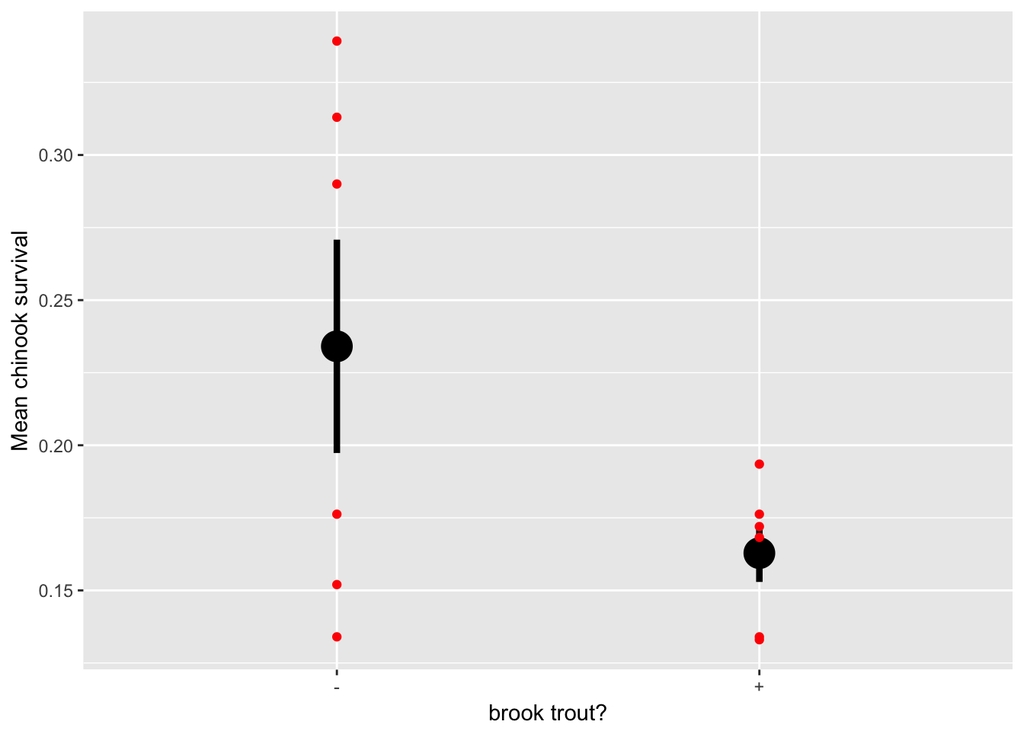

```r
salmon_means+
  geom_point(color="red")
```

#### 1.4 Workflow and Faded Examples

As we’ve talked about, our general workflow for an analysis is

1. Build a Test
2. Evaluate Assumptions of Test
3. Evaluate Results
4. Visualize Results

If we’ve decided on a t-test, we’ve satisfied #1. So let’s go through a few examples where we load up our data, evaluate assumptions, evaluate the results of our test, and visualize the results.

We’ll start with the salmon example, all in one place.

```r
#Load and visualize data
chinook <- read_csv("./data/12e4BrookTrout.csv")
```

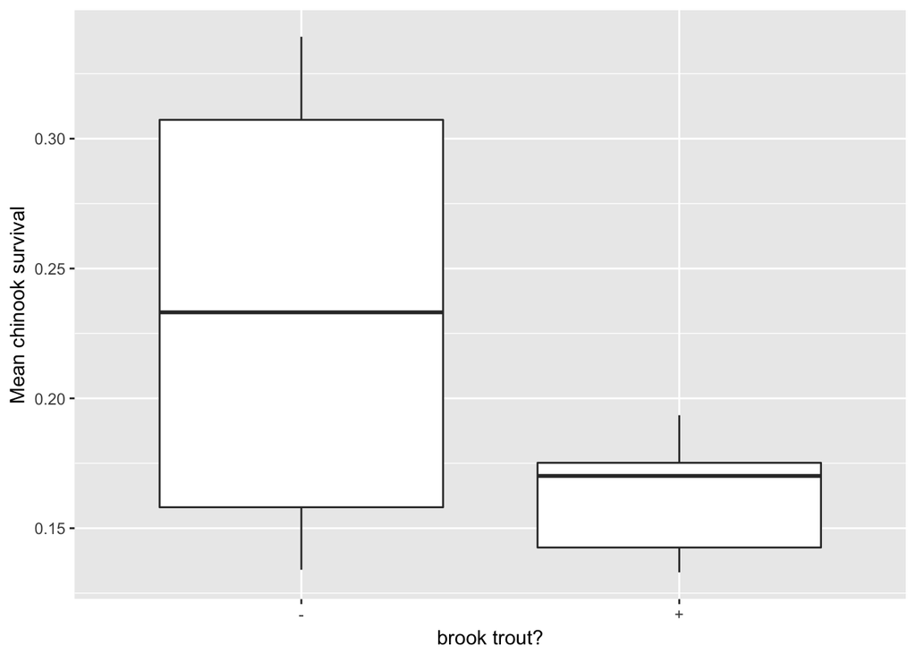

```r
ggplot(data=chinook, mapping=aes(x=`brook trout?`, y=`Mean chinook survival`)) +
  geom_boxplot()
```

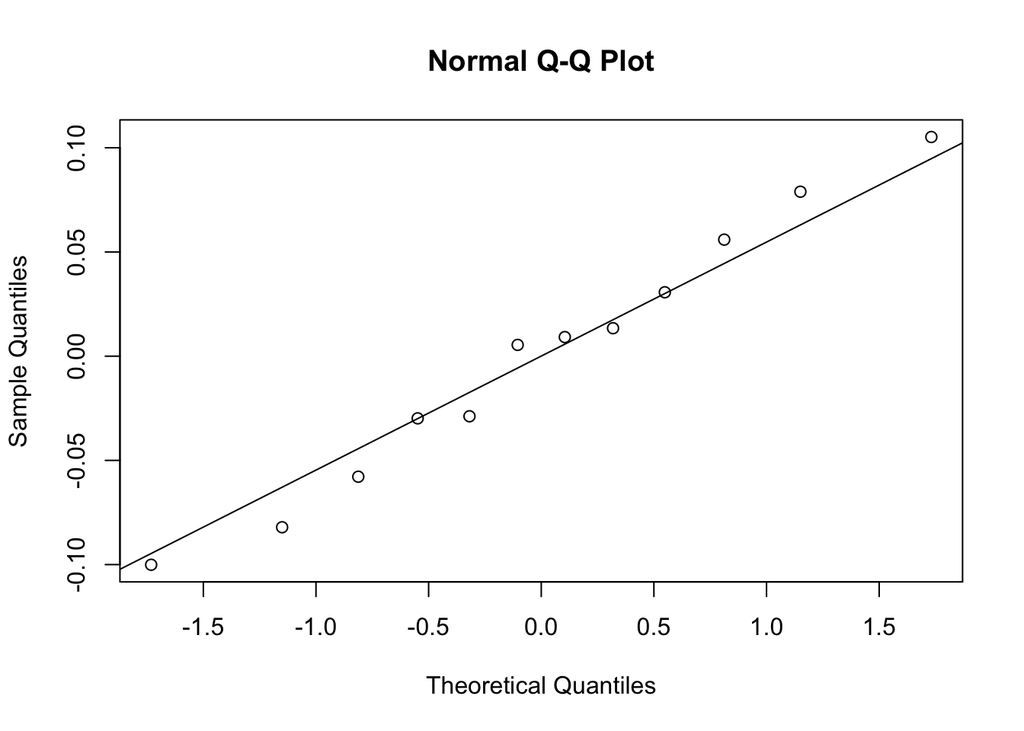

```r
## test assumptions
chinook <- chinook %>%
  group_by( `brook trout?`) %>%
  mutate(resid =
           `Mean chinook survival` - mean(`Mean chinook survival`)) %>%
  ungroup()

#qq
qqnorm(chinook$resid)
qqline(chinook$resid)
```

```r
shapiro.test(chinook$resid)
```

```
##
##  Shapiro-Wilk normality test
##
## data:  chinook$resid
## W = 0.97827, p-value = 0.9758
```

```r
#put it to the test!
t.test(`Mean chinook survival` ~ `brook trout?`, data = chinook,
       unequal.var = TRUE)
```

```
##
##  Welch Two Sample t-test
##
## data:  Mean chinook survival by brook trout?
## t = 1.8718, df = 5.7256, p-value = 0.1127
## alternative hypothesis: true difference in means is not equal to 0
## 95 percent confidence interval:
##  -0.02298513  0.16548513
## sample estimates:
## mean in group - mean in group +
##       0.2340833       0.1628333
```

```
## No summary function supplied, defaulting to `mean_se()
```

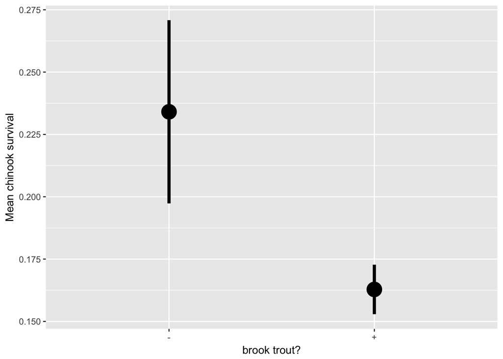

```r
ggplot(data=chinook,
                       mapping=aes(x=`brook trout?`,
                                   y=`Mean chinook survival`)) +
  stat_summary(size=1.5)
```

OK, now that we have this, let’s apply the same strategy to Cichlid habitat preferences that vary by genotypes.

```r
#Load and visualize data
cichlid <- read_csv("./data/12q09Cichlids.csv")

ggplot(data=cichlid, mapping=aes(x=Genotype, y=preference)) +
  ____()

## test assumptions
cichlid <- cichlid %>%
  group_by(____) %>%
  mutate(resid =
          preference - mean(preference)) %>%
  ungroup()

#qq
qqnorm(cichlid$____)
qqline(cichlid$____)

shapiro.test(cichlid$____)

#put it to the test!
t.test(____ ~ ____, data = ____,
       unequal.var = TRUE)

ggplot(data=cichlid, mapping=aes(x=____,y=____)) +
  stat_summary(size=1.5)
```

And now for how monogamy influences testes size

```r
#Load and visualize data
monogomy <- ____("./data/12q05MonogamousTestes.csv")

ggplot(data=____, mapping=aes(x=`Column 1` , y=`Testes area`)) +
  ____()

## test assumptions
monogomy <- monogomy %>%
  group_by(____) %>%
  ____(resid =
          `Testes area` - ____(____)) %>%
  ungroup()

#qq
____(____)
____(____)

shapiro.test(____)

#put it to the test!
t.test(____ ~ ____ , data = monogomy,
       unequal.var = ____)

ggplot(data=____, mapping=aes(x=____ ,y=____)) +
  ____(size=1.5)
```